# Unsupervised Machine Learning - Clustering using K- Means

# - Univariate analysis

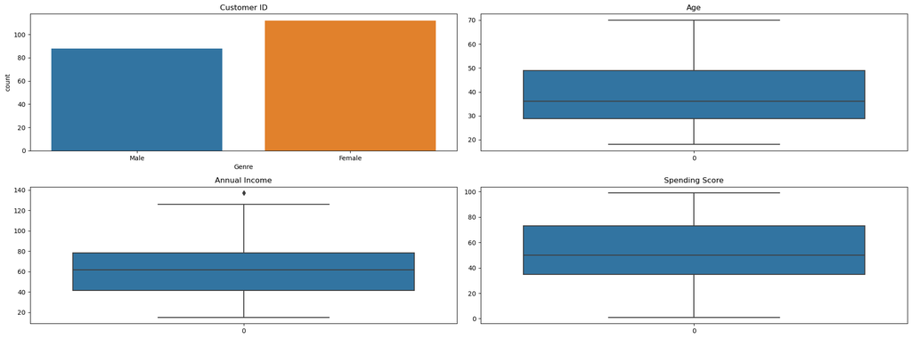

```python
# I am checking four columns out of the five using a subplot

# Create a 2x2 grid for subplots
fig, axs = plt.subplots(2, 2, figsize=(20, 7.5))

# Plot the data on each subplot
plt1 = sns.countplot(x=data['Genre'], ax=axs[0, 0])
axs[0, 0].set_title('Customer ID')

plt2 = sns.boxplot(data['Age'], ax=axs[0, 1])
axs[0, 1].set_title('Age')

plt3 = sns.boxplot(data['Annual_Income_(k$)'], ax=axs[1, 0])
axs[1, 0].set_title('Annual Income')

plt4 = sns.boxplot(data['Spending_Score'], ax=axs[1, 1])
axs[1, 1].set_title('Spending Score')

plt.tight_layout()
```

More females than males, the annual income has one outlier, the other box plot are relatively self explanatory

```python
data['Annual_Income_(k$)'].unique()
```

```
array([ 15,  16,  17,  18,  19,  20,  21,  23,  24,  25,  28,  29,  30,
        33,  34,  37,  38,  39,  40,  42,  43,  44,  46,  47,  48,  49,
        50,  54,  57,  58,  59,  60,  61,  62,  63,  64,  65,  67,  69,
        70,  71,  72,  73,  74,  75,  76,  77,  78,  79,  81,  85,  86,
        87,  88,  93,  97,  98,  99, 101, 103, 113, 120, 126, 137],
      dtype=int64)
```

```python
data['Age'].unique()
```

```
array([19, 21, 20, 23, 31, 22, 35, 64, 30, 67, 58, 24, 37, 52, 25, 46, 54,
       29, 45, 40, 60, 53, 18, 49, 42, 36, 65, 48, 50, 27, 33, 59, 47, 51,
       69, 70, 63, 43, 68, 32, 26, 57, 38, 55, 34, 66, 39, 44, 28, 56, 41],
      dtype=int64)
```

```python
# I am creating age group

def age_bracket(age):
    if age <= 30:
        return 'Youths (<30)'
    elif age <= 50:
        return 'Middle age (30-50)'
    else:
        return 'Older adults'

data['age_bracket'] = data['Age'].apply(age_bracket)
```

[output not shown]

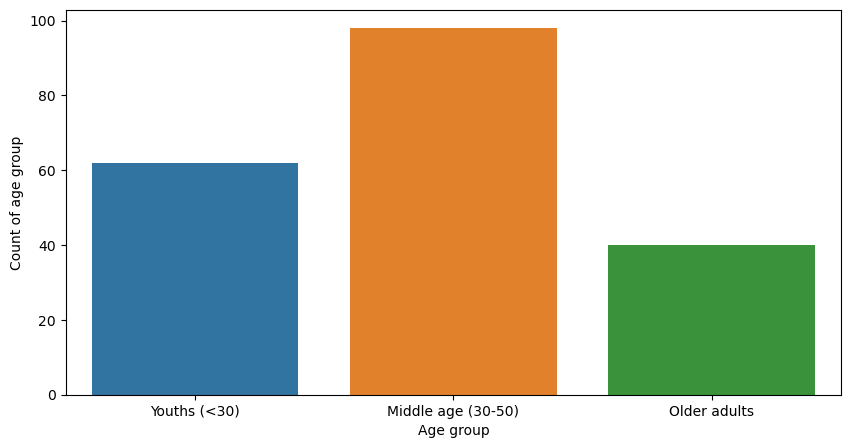

```python
plt.figure(figsize = (10,5))

sns.countplot(x='age_bracket', data=data)
plt.xlabel("Age group")
plt.ylabel('Count of age group')
plt.title
```

The highest customer age group falls between 30-50 years followed by the youths and finally the older adults

```python
# I am creating 'Annual_Income_(k$)' group

def annual_income(income):
    if income <= 40:
        return 'low income (<40)'
    elif income <= 70:
        return 'middle income (40-70)'
    elif income <= 100:
        return 'high income (70-100)'
    else:
        return 'wealthy'

data['annual_income'] = data['Annual_Income_(k$)'].apply(annual_income)
```

[output not shown]

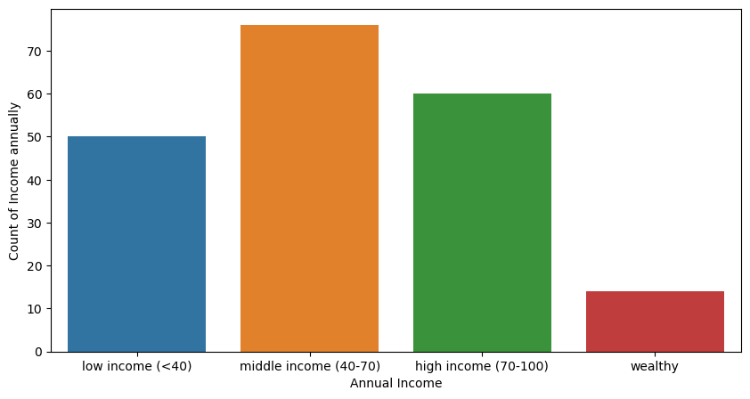

```python
plt.figure(figsize = (10,5))

sns.countplot(x='annual_income', data=data)
plt.xlabel("Annual Income")
plt.ylabel('Count of Income annually')
plt.title
```

The middle income earners visit the store more regularly than the high income earners, and low income earners. The wealth group are the smallest group visiting the store. But who spend More?

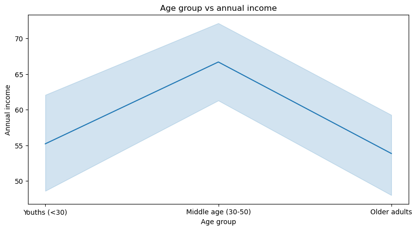

```
(None,)
```

```python
plt.figure(figsize = (10,5))

sns.lineplot(x='age_bracket', data=data, y= 'Annual_Income_(k$)')
plt.xlabel("Age group")
plt.ylabel('Annual income')
plt.title('Age group vs annual income')
plt.show(),
```

The middle age group are the highest income earners

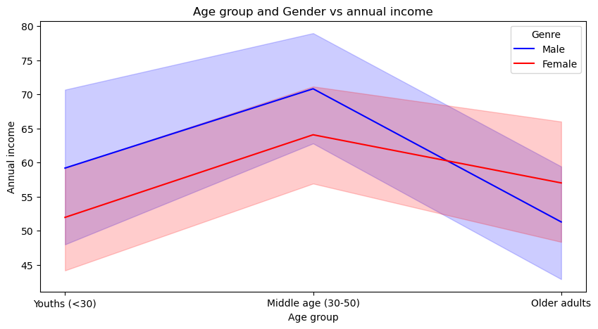

```
(None,)
```

```python
plt.figure(figsize = (10,5))

custom_palette = {'Male': 'blue', 'Female': 'red'} # Assign a color palette to the gender

sns.lineplot(x='age_bracket', data=data, y= 'Annual_Income_(k$)', hue = 'Genre', palette = custom_palette)
plt.xlabel("Age group")
plt.ylabel('Annual income')
plt.title('Age group and Gender vs annual income')
plt.show(),
```

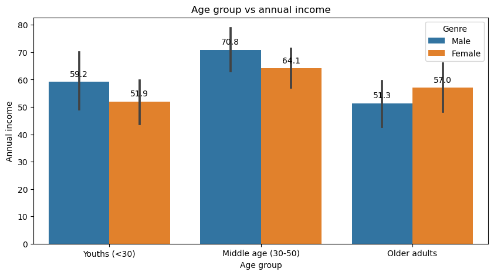

```
(None,)
```

```python
plt.figure(figsize = (10,5))

ax = sns.barplot(x='age_bracket', data=data, y= 'Annual_Income_(k$)', hue = 'Genre' )
plt.xlabel("Age group")
plt.ylabel('Annual income')
plt.title('Age group vs annual income')

#to shwo the number on the bar
# Adding the numbers on top of the bars
for p in ax.patches:
    height = p.get_height()
    ax.text(p.get_x() + p.get_width() / 2., height + 2, f'{height:.1f}', ha="center")

plt.show(),
```

The male gender earn more income in the youth and the middle age group age bracket while it is a reverse at the older adult age group

```python
data['Spending_Score'].unique()
```

```
array([39, 81,  6, 77, 40, 76, 94,  3, 72, 14, 99, 15, 13, 79, 35, 66, 29,
       98, 73,  5, 82, 32, 61, 31, 87,  4, 92, 17, 26, 75, 36, 28, 65, 55,
       47, 42, 52, 60, 54, 45, 41, 50, 46, 51, 56, 59, 48, 49, 53, 44, 57,
       58, 43, 91, 95, 11,  9, 34, 71, 88,  7, 10, 93, 12, 97, 74, 22, 90,
       20, 16, 89,  1, 78, 83, 27, 63, 86, 69, 24, 68, 85, 23,  8, 18],
      dtype=int64)
```

```python
data['Spending_Score'].max()
```

```
99
```

```python
data['Spending_Score'].min()
```

```
1
```

```python
# I am creating 'Spending Score' group

def spend_scr(spending):
    if spending <= 25:
        return 'low score (<25)'
    elif spending <= 50:
        return 'middle score (<50)'
    elif spending <= 75:
        return 'high score (<75)'
    else:
        return 'highest score(<100)'

data['spend_scr'] = data['Spending_Score'].apply(spend_scr)
```

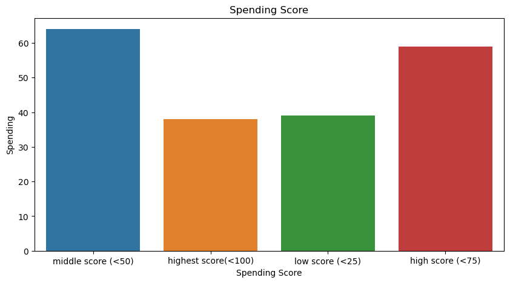

```python
plt.figure(figsize = (10,5))

sns.countplot(x='spend_scr', data=data)
plt.xlabel("Spending Score")
plt.ylabel('Spending')
plt.title('Spending Score')
```

Majority of the spenders spending between > 25 to < 75

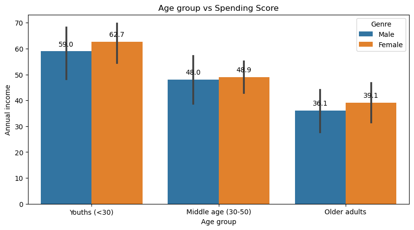

```
(None,)
```

```python
# Now, to look at the income earners, gender, and spending ability

plt.figure(figsize = (10,5))

ax = sns.barplot(x='age_bracket', data=data, y= 'Spending_Score', hue = 'Genre' )
plt.xlabel("Age group")
plt.ylabel('Annual income')
plt.title('Age group vs Spending Score')

#to shwo the number on the bar
# Adding the numbers on top of the bars
for p in ax.patches:
    height = p.get_height()
    ax.text(p.get_x() + p.get_width() / 2., height + 2, f'{height:.1f}', ha="center")

plt.show(),
```

The age group "Youths" are earn less, but has the highest spending score in the store (with more females than males), The middle age group are the highest earners but less spending score than the "Youths" while the older adults are the least spenders.

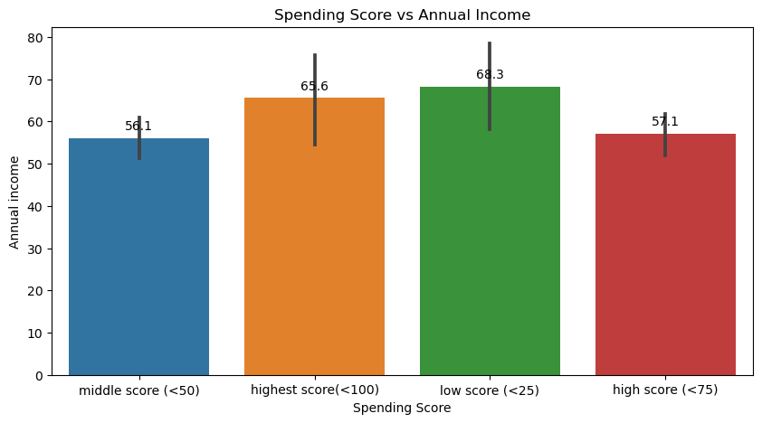

```
(None,)
```

```python
plt.figure(figsize = (10,5))

ax = sns.barplot(x='spend_scr', data=data, y= 'Annual_Income_(k$)')
plt.xlabel("Spending Score")
plt.ylabel('Annual income')
plt.title('Spending Score vs Annual Income')

#to shwo the number on the bar
# Adding the numbers on top of the bars
for p in ax.patches:
    height = p.get_height()
    ax.text(p.get_x() + p.get_width() / 2., height + 2, f'{height:.1f}', ha="center")

plt.show(),
```

The "Low score group" of the spending score are the highest income earners, followed by the "highest score group". The customers that belong to the "high score group" and the "middle score group" are the least annual income earners respectively.

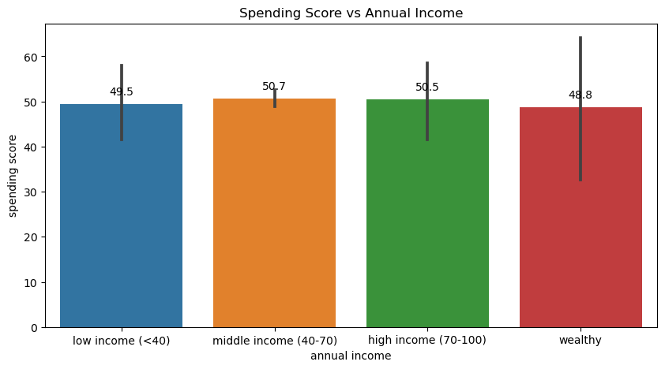

```python
plt.figure(figsize = (10,5))

ax = sns.barplot(x='annual_income', data=data, y= 'Spending_Score')
plt.xlabel("annual income")
plt.ylabel('spending score')
plt.title('Spending Score vs Annual Income')

#to shwo the number on the bar
# Adding the numbers on top of the bars
for p in ax.patches:
    height = p.get_height()
    ax.text(p.get_x() + p.get_width() / 2., height + 2, f'{height:.1f}', ha="center")

plt.show()
```

The wealthy people and the low income earners have low spending score compared with high and middle income earners.

```python
data.corr()
```

|  | CustomerID | Age | Annual_Income_(k$) | Spending_Score |
| --- | --- | --- | --- | --- |
| CustomerID | 1.000000 | -0.026763 | 0.977548 | 0.013835 |
| Age | -0.026763 | 1.000000 | -0.012398 | -0.327227 |
| Annual_Income_(k$) | 0.977548 | -0.012398 | 1.000000 | 0.009903 |
| Spending_Score | 0.013835 | -0.327227 | 0.009903 | 1.000000 |

```python
corr_matrix = data.corr()
```

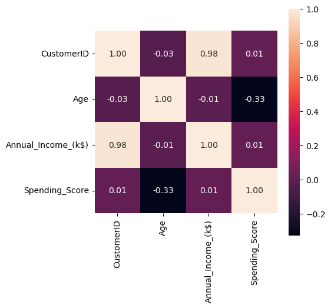

```python
# Using a correlation table, I want to see the significance of the the spenders and incomer earners.

plt.figure(figsize =(5,5))

sns.heatmap(corr_matrix, cbar=True, annot=True, square=True, fmt='.2f',annot_kws={'size':10})
```

```python
data.head(1)
```

|  | CustomerID | Genre | Age | Annual_Income_(k$) | Spending_Score | age_bracket | annual_income | spend_scr |
| --- | --- | --- | --- | --- | --- | --- | --- | --- |
| 0 | 1 | Male | 19 | 15 | 39 | Youths (<30) | low income (<40) | middle score (<50) |

I do not need the customer ID, I will drop it from here

# Machine Learning (Unsupervised)

```python
data1 = data[['CustomerID', 'Genre', 'Age', 'Annual_Income_(k$)', 'Spending_Score']]
```

I am changing categorical variable to numerical variable here to deploy the ML algorithm

```python
# Label encoding #Get dummy variables makes it more difficult, hence I use label encoder more

from sklearn.preprocessing import LabelEncoder

# Changing my categorical variables to numerical variables

encoder = LabelEncoder() # method initialisation

# Looping for columns except Survived

for c in data1.columns[1:]: #it is indexing the column one after the other, rather than using data1.column()
    if (data1[c].dtype == 'object'):
        data1[c] = encoder.fit_transform(data1[c])
    else:
        data1[c] = data1[c]


data1.head()
```

|  | CustomerID | Genre | Age | Annual_Income_(k$) | Spending_Score |
| --- | --- | --- | --- | --- | --- |
| 0 | 1 | 1 | 19 | 15 | 39 |
| 1 | 2 | 1 | 21 | 15 | 81 |
| 2 | 3 | 0 | 20 | 16 | 6 |
| 3 | 4 | 0 | 23 | 16 | 77 |
| 4 | 5 | 0 | 31 | 17 | 40 |

Here, Male has been changed to 1, and female changed to 0

```python
# Droping the customer ID and remove any unique identifier for any data. REMOVE ALL UNOQUE IDENTIFIER

data1.drop('CustomerID', axis =1, inplace = True)

data1.head(1)
```

|  | Genre | Age | Annual_Income_(k$) | Spending_Score |
| --- | --- | --- | --- | --- |
| 0 | 1 | 19 | 15 | 39 |

[output not shown]

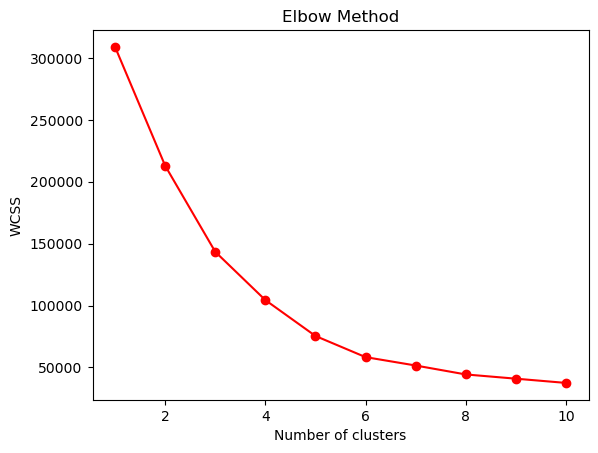

```python
# How many clusters do i want to create?
# I will deploy the ML to choose the clusters best for the data using the ELBOW METHOD

wcss = []
for i in range (1,11): # range of 1 to 10
    kmeans = KMeans(n_clusters =i, init='k-means++', random_state=42)
    kmeans.fit(data1)
    wcss.append(kmeans.inertia_)

#visulised

plt.plot(range(1, 11), wcss, color = 'red', marker = 'o')
plt.title('Elbow Method')
plt.xlabel('Number of clusters')
plt.ylabel('WCSS')
plt.show()
```

The elbow here is between 4 and 6

```python
data1.head(1)
```

|  | Genre | Age | Annual_Income_(k$) | Spending_Score |
| --- | --- | --- | --- | --- |
| 0 | 1 | 19 | 15 | 39 |

```python
# Fit K-Means clusterings model
kmeans = KMeans(n_clusters = 5, init = 'k-means++', random_state = 42) # I am doing 5 clusters to go randomly in 42 times
kmeans.fit(data1)


#Add clusters labels to data
data1['Clusters'] = kmeans.labels_
```

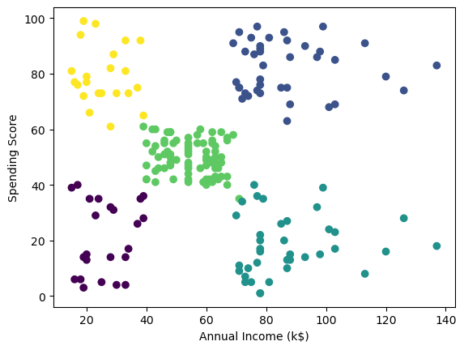

```
0.44493777835059417
```

```python
# Visualise Clusters results

plt.scatter(data1['Annual_Income_(k$)'], data1['Spending_Score'], c=data1['Clusters'], label='Centroids')
plt.xlabel('Annual Income (k$)')
plt.ylabel('Spending Score')
plt.show()


#calculate the silhoutte score

from sklearn.metrics import silhouette_score

silhouette_score(data1, kmeans.labels_)
```

Here, there are two sets of low income earners 'purple' and 'yellow' and there spending score really differ. Part of them have a high spending score while the purple are low spenders.

The middle income earners in green color have a middle spending score as well

The high income earners 'torquoise' and 'blue' are divided into two segments. The 'Blue' category have a high score while the 'torquorise' have a low spending score

Hence, we have a clusterings

The silhouette score of 0.44493777835059417 indicates that the clusters are moderately well-separated